# Two Denominators for Turnout

One numerator, two denominators, and a thirty-year decline that is not in the data

Democracy’s Data

Last updated September 13, 2026 at 10:53a EDT

156,766,239 ballots were counted in the November 2024 general election. Nobody disputes that number, and it will not change again. Divide it by one population and American turnout in 2024 was **59.2%**. Divide it by another and it was **64.3%**.

So what *is* the turnout rate? The question is not pedantic. A turnout rate is how a country grades its own democracy, and the American figure is the one quoted in every league table that ranks the United States against other rich democracies. Both populations below are published by serious people, both are called something reasonable, and both describe the United States in November 2024. The gap between the two answers is 5.1 points, worth 13,500,287 ballots.

## The test

This brief joins one numerator, the top number of a fraction, to two competing denominators. A denominator is the bottom number, the thing you are dividing by. The ballots and the populations come from the same two files, matched row to row on the election year for the national series and on state and year for the fifty states.

The 1948–2000 half is Table 1 of Michael McDonald and Samuel Popkin’s *The Myth of the Vanishing Voter*, the 2001 article that introduced the voting-eligible population, printed on page 966 of the December 2001 *American Political Science Review* (https://www.jstor.org/stable/3117725). The 1980–2024 half is the turnout tables of the United States Elections Project, which McDonald, a political scientist at the University of Florida, has maintained since; they are downloadable as CSV under a Creative Commons licence at https://election.lab.ufl.edu/data-downloads/.

Those two sources answer the question because they are the only ones that print the ballots next to *both* candidate denominators for the same elections. Anyone can recompute either rate and compare. The join runs on a well-behaved key: a year and a state name are about as safe as keys get, which is why the interesting failure here is not in the join. Join Keys and Crosswalks is the chapter on what a key can promise, and on the crosswalk, a table that translates one set of identifiers into another when two files share no key.

## The data

Five tables carry this brief. `mp1948.csv` holds the article’s own table, 27 rows covering 1948-2000, with `year`, `vote_highest`, `vap`, `vap_rate`, the three adjustments (`noncitizens`, `felons`, `overseas`), `vep`, `vep_rate` and `inelig_pct`. `national.csv` and `states.csv` hold the modern series, 1,196 rows in all, with `YEAR`, `STATE`, `TOTAL_BALLOTS_COUNTED`, `VOTE_FOR_HIGHEST_OFFICE`, `VAP`, `VEP`, `NONCITIZEN_PCT`, `INELIGIBLE_FELONS_TOTAL`, `ELIGIBLE_OVERSEAS` and the four rates this brief computes from them. `state_trends.csv` fits both trends per state and flags `sign_flip`; `pairs2024.csv` compares every pair of states on both denominators.

The **voting-eligible population**, VEP in the figures, is not a mysterious quantity. Start from the **voting-age population**, VAP, which is everyone aged 18 and over living in the country, citizen or not, free or not. Subtract the people in it who cannot vote and add the people who can vote and are not in it.

| Term | Who that is |
| --- | --- |
| Voting-age population | everyone aged 18 and over living in the country |
| less noncitizens | in the country, cannot vote |
| less ineligible felons | citizens, barred by their state over a conviction |
| plus eligible overseas | citizens who may vote and do not live here |
| Voting-eligible population | the people who could have cast a ballot |

Two construction decisions matter more than the rest.

**The older half is typesetting, not a file.** There is no dataset behind the 1948–2000 series. The numbers exist as an arrangement of characters on a printed page, and were recovered here by reading the text of the article’s PDF. Public is not the same as usable: a number can be authoritative, cited for twenty-five years, and still not be a dataset. Two checks catch misread digits: the printed voting-eligible rate is recomputed from the printed ballots and population, and the printed adjustments are added up to see that they reach it. All 27 rows reconstruct within 0.05 of a percentage point.

**The modern file carries two numerators, and they are never spliced.** `VOTE_FOR_HIGHEST_OFFICE` counts votes for the top statewide contest; `TOTAL_BALLOTS_COUNTED` counts every ballot, including those where the voter skipped that contest. The second runs two to three per cent higher, and the two cover different years. Joining them end to end inserts a jump larger than most of the effects below, so every trend here is computed on one numerator at a time. That is why the state analysis stops at 2016 rather than 2024.

> **Before you read on, commit to a number.** Divided by the voting-age population, presidential turnout fell **0.56 points per election** across 1972–2000. Divided by the voting-*eligible* population, with the same elections and the same ballots, **how much did it fall?** Half as fast? A third?

## What it says about democracy

**-0.006 points per election.** Not half, and not a third. The corrected series falls by 0.04 of a percentage point across the whole of 1972 to 2000, with a standard error, the margin of doubt around a fitted slope, 67 times the estimate itself. It cannot be told apart from a flat line.

| Denominator | 1972 | 2000 | Trend per election | Standard error |
| --- | --- | --- | --- | --- |
| Voting-age population (VAP) | 55.2 | 51.2 | -0.564 | 0.29 |
| Voting-eligible population (VEP) | 56.2 | 55.6 | -0.006 | 0.40 |

That matters because of what the falling version was used for. By the late 1990s the decline of American voter participation was, in the words of Steven Rosenstone and John Mark Hansen’s standard text on the subject, the most analyzed trend in recent American political history.[^1] Turnout had run near 62.8% in 1960 and was down to 48.9% by 1996. Television had done it, or negative advertising, or the collapse of party organizations, or the decline of social capital. Every one of those explanations was an explanation of the same measurement.

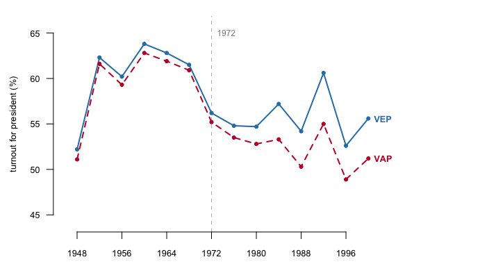

**Figure 1. Presidential turnout, 1948–2000, the same ballots over two denominators.** Two lines on one axis is the right form here because the two series share a numerator exactly: any daylight between them is the denominator and nothing else. Before 1972 they are nearly the same line. After it they separate, and the red line goes down while the blue one does not.

The reason the choice changes a trend rather than only a level is that the error is not a constant. If the voting-age population had always overstated the electorate by the same proportion, every year’s rate would sit too low by the same amount and the slope would be untouched.

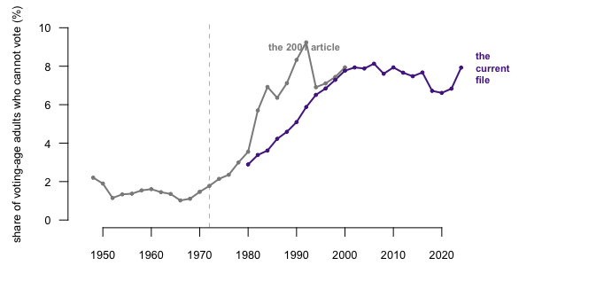

**Figure 2. The share of the voting-age population that cannot vote, 1948–2024.** There are no ballots in this figure at all; it is a statement about who lives here. The share runs about 1.0% at the low point in the 1960s and 7.9% in 2024. A growing correction subtracted from a flat series *is* a declining series.

The vanishing voter was never a fact about voters. It was a fact about immigration, incarceration and Census arithmetic, entering the literature through the bottom of a fraction that nobody was reading. Here is the same arithmetic for one recent election.

| Step | People |
| --- | --- |
| Voting-age population, November 2024 | 264,798,961 |
| less noncitizens | -21,713,515 |
| less people in prison, on probation or on parole where that bars voting | -2,609,565 |
| plus citizens living overseas who may vote | +3,325,217 |
| Voting-eligible population | 243,803,423 |

Noncitizens are 89.3% of everything subtracted, which is why the correction tracks immigration so closely and why it grew when it did.

Take one state through the same steps. Texas had 23,513,616 residents of voting age in November 2024. 12.6% of them, 2,969,770 people, were not citizens. A further 485,781 were in prison, on probation or on parole for a felony, and Texas bars all three from voting. Subtract both and 20,059,077 people could have cast a ballot; the state rows carry no overseas line, because the publisher does not spread those citizens across states, and the subtraction lands within 1,012 people of the file’s own figure. The file records 11,400,000 ballots, a visibly rounded number. Divide by the first population and Texas turnout was 48.5%; divide by the second and it was 56.8%, 8.3 points higher from the same ballots.

Noncitizens are also not spread evenly. In 2024 they are 15.0% of the voting-age population in California and 1.1% in West Virginia. Fit the same two lines for each state across the 10 presidential elections from 1980 to 2016 and 5 states come out with turnout falling on one denominator and rising on the other.

| State | Noncitizen share | Fitted change on VAP | Fitted change on VEP |
| --- | --- | --- | --- |
| Texas | 4.3% to 13.3% | -3.4 pts | +2.6 pts |
| Arkansas | 0.5% to 3.8% | -2.7 pts | +0.3 pts |
| Kansas | 1.1% to 5.2% | -2.5 pts | +0.8 pts |
| California | 10.8% to 16.4% | -2.0 pts | +1.3 pts |
| Illinois | 4.1% to 8.5% | -1.6 pts | +2.0 pts |

Texas is the clearest case, falling 3.4 points against everyone of voting age and rising 2.6 points against everyone allowed to vote. Now the honest part, which is the more useful lesson of the two. **Not one of the 10 trends in that table is statistically distinguishable from zero**: the margin of doubt around each fitted slope is wide enough to include no change at all. 36 of the 102 state trends across all 51 jurisdictions do clear the conventional threshold for calling a trend real, so this is not a claim that ten elections can never establish anything. The sign flips where neither slope is well determined, which is exactly where you would expect it.

That is the finding, not a caveat on it. The denominator decides which of two unsupported stories the data appears to tell, and a reader shown only one line has no way to know the other exists.

One comparison carries no such uncertainty, because it is two divisions rather than two estimates of a slope. Of the 1,275 distinct pairs of states in 2024, 127 rank one way under one denominator and the opposite way under the other.

| Denominator | California | West Virginia | Turned out more |
| --- | --- | --- | --- |
| Voting-age population | 52.7% | 54.4% | West Virginia |
| Voting-eligible population | 62.3% | 55.6% | California |

West Virginia beats California by 1.7 points, or loses to it by 6.7 points, depending on which population goes underneath. Both statements are computed from the same certified ballot counts.

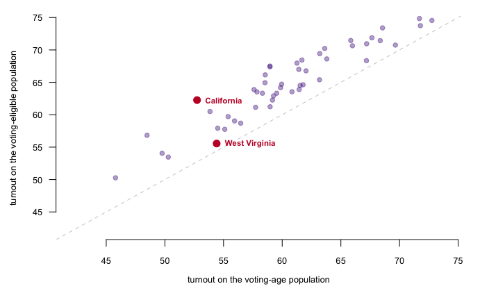

**Figure 3. Every state in 2024, measured both ways.** Every state sits above the diagonal, because every state has somebody in it who cannot vote. What varies is how far above, from 1.1 points in Vermont to 9.5 points in California. A ranking compares vertical positions, and the vertical positions have been shifted by different amounts.

## What this brief cannot tell you

**The denominator is an estimate, not a count.** Voting-age population comes from Census projections between the decennial counts, and the noncitizen share from the American Community Survey. The felon population comes from Bureau of Justice Statistics series, and the overseas figure is projected forward from a single survey. None of them carries anything saying how far off it could be. The voting-eligible population is a better denominator, not a measured one.

**None of the five sign changes rests on a significant trend.** They show how sensitive a conclusion is to a choice of denominator. They do not establish that turnout rose anywhere, and the claim that Texas turnout fell is not supported either.

**The better denominator is still wrong.** It subtracts people in prison, on probation and on parole where state law bars them from voting, taking the state rules from the National Conference of State Legislatures’ summary.[^2] It does not subtract people who have completed a sentence in full and remain barred, because the maintainer reports having no reliable way to estimate that population and says so in the documentation. Residency requirements are not adjusted for by either source.

**And the 2024 figures are a version 0.x release.** Some state ballot counts in that file are visibly rounded estimates rather than certifications, and the publisher still calls the file preliminary.

## What you should have learned

- The same 156,766,239 ballots give a 2024 turnout rate of 59.2% or 64.3%, 5.1 points apart, worth 13,500,287 ballots, depending only on which population sits underneath.
- Presidential turnout from 1972 to 2000 falls 0.56 points per election on the voting-age population and -0.006 on the voting-eligible population, so an entire research literature was explaining a denominator.
- The correction is not a level shift: the share of voting-age adults who cannot vote runs from about 1.0% in the 1960s to 7.9% in 2024, and a growing correction turns a flat series into a declining one.
- 5 states change the direction of their turnout trend with the denominator, and 127 of 1,275 state pairs swap places in a 2024 ranking.
- A denominator is a claim about who counts, every such claim is contestable, and the honest move is to say which one you used and why.

## Extensions

None of these is answered above, and every one can be answered from the tables the Sources section hands over.

- `state_trends.csv` carries `b_vap`, `b_vep` and `sign_flip`. Sort by `divergence` and read the twenty states where the two denominators disagree most, whether or not the sign changes.
- `pairs2024.csv` has `vap_a`, `vap_b`, `vep_a`, `vep_b` and `swing`. Sort by `swing` and list the ten pairs the choice of denominator reverses most sharply. Do the same states keep appearing?
- `mp1948.csv` shows the adjustments one at a time in `noncitizens`, `felons` and `overseas`. Work out which one matters most in 1960 and which matters most in 2000.
- `states.csv` has `NONCITIZEN_PCT` and `inelig_pct` for every state and year. Rank the states by how much their correction grew between 1980 and 2024.
- **Stretch.** Several other democracies publish turnout over a registered-voter denominator rather than an age or eligibility one. Find two, and work out which American figure their number should be compared against.
- **Stretch.** The Sentencing Project counts Americans who have completed a felony sentence and remain barred from voting. Download that number, subtract it from the voting-eligible population, and see how far the 2024 rate moves.

## Sources

**Data**

- McDonald, Michael P., and Samuel L. Popkin. 2001. “The Myth of the Vanishing Voter.” *American Political Science Review* 95 (4): 963–974. https://www.jstor.org/stable/3117725 Table 1, page 966, read from the article’s PDF into the plain-text file `mp2001-table1.txt`. 27 election years, 1948-2000. See `README.txt` for what was and was not altered.
- McDonald, Michael P. *1980–2022 General Election Turnout Rates*, version 1.2. United States Elections Project, University of Florida. CC BY 4.0. https://election.lab.ufl.edu/data-downloads/turnoutdata/Turnout_1980_2022_v1.2.csv
- McDonald, Michael P. *2024 General Election Turnout Rates*, version 0.4. United States Elections Project, University of Florida. https://election.lab.ufl.edu/data-downloads/turnoutdata/Turnout_2024G_v0.4.csv Both files’ documentation is kept alongside them and quoted above.
- National Conference of State Legislatures. *Felon Voting Rights*, the state-by-state rules the turnout files use to decide who is barred. https://www.ncsl.org/elections-and-campaigns/felon-voting-rights

**The data itself**

Every figure above is drawn from these tables. They are plain CSV, they open in a spreadsheet, and they are yours to take further.

`mp1948.csv`, `national.csv`, `overlap.csv`, `pairs2024.csv`, `state_trends.csv`, `states.csv`

One more file is not data about the subject – it is how this chapter checked its own work: `checks.csv`, the arithmetic verified before anything was drawn.

**Also cited**

- Rosenstone, Steven J., and John Mark Hansen. 1993. *Mobilization, Participation, and Democracy in America.* New York: Macmillan — the characterisation of the decline as the most analyzed trend in recent American political history, quoted at the opening of the 2001 article.
- Teixeira, Ruy. 1992. *The Disappearing American Voter.* Washington, DC: Brookings Institution — the case for the voting-age population as the denominator, which the 2001 article argues against.
- Putnam, Robert D. 2000. *Bowling Alone.* New York: Simon and Schuster — one of the explanations offered for the decline that turns out not to need explaining.

Rebuild this data yourself, with an AI assistant

```
I want to rebuild a public dataset from its original sources, without
any starting files. Please do the following and show your work.

THE FIRST SOURCE. The United States Elections Project at the
University of Florida, general-election turnout rates, two CSVs:
https://election.lab.ufl.edu/data-downloads/turnoutdata/Turnout_1980_2022_v1.2.csv
https://election.lab.ufl.edu/data-downloads/turnoutdata/Turnout_2024G_v0.4.csv
Each row is one state (or the national total) in one election, with
the voting-age population, the voting-eligible population, and the
pieces separating them. No account or key is needed. The version
numbers in those addresses will move — if one answers 404, start from
https://election.lab.ufl.edu/data-downloads/ and take the current
version. A 0.x version means the publisher still calls it preliminary.

THE SECOND SOURCE. McDonald and Popkin, "The Myth of the Vanishing
Voter", American Political Science Review 95(4), 2001, Table 1 on
page 966 — the 1948-2000 half of the series exists only as a table
printed in that article. It sits behind JSTOR
(https://www.jstor.org/stable/3117725), so it cannot be downloaded
openly; anyone with library access can read it there and key in its
27 rows by hand.

WHAT TO BUILD.
1. From the article's table: the printed VEP turnout rate for each
   election, and the same rate rebuilt from the table's own component
   columns, to confirm the arithmetic of the paper.
2. From the modern files: national turnout on both denominators,
   1980-2024 — keeping the two numerators (highest-office votes and
   total ballots) apart, because the file's own rate columns switch
   numerators partway and splicing them fakes a jump around 1998.

CHECK YOUR WORK. The copies this book used were downloaded in August
2026. If your rebuild matches them, you should find:
- 27 data rows in the article's table, 1948 through 2000, and the
  rebuilt VEP rate lands within 0.1 points of the printed one in
  all 27
- 1,144 rows in the 1980-2022 file and 52 in the 2024 file
- across all 1,196 modern rows, the eligible population equals the
  voting-age population less noncitizens and felons, plus overseas
  voters, within a tenth of a percent
The publisher revises these files and bumps the version string; a
2024 file past v0.4 means numbers were revised, not that you erred.
```

[^1]: Steven J. Rosenstone and John Mark Hansen, *Mobilization, Participation, and Democracy in America* (New York: Macmillan, 1993), quoted in the opening paragraph of McDonald and Popkin’s 2001 article.
[^2]: The file’s documentation names its source for who is barred where: https://www.ncsl.org/elections-and-campaigns/felon-voting-rights.